# Random Forests & Boosting

Ensemble-Methods in Machine Learning

Binh-Nguyen Vu, Lino von Waldthausen, Zhen Rong, Joshua Arbinger, Zhihao Zheng

2026-06-09

## Table of Content

**Bias-Variance**

1. Last week: Decision Trees
2. The Bias-Variance-Tradeoff
3. Deep Trees
4. Paradigm Shift

**Bootstrap & Bagging**

5. Bootstrap & Bootstrap Sampling
6. Estimating many Trees
7. In- vs. Out-of-Bag
8. OOB-Error

**Random Forests**

9. Random Forest
10. Decorrelation of Trees

**Boosting**

**Boosting Libraries**

23. Modern Libraries
24. Common Workflow
25. Demo: Breast Cancer

## Last week: Decision Trees

Bias

- ability to capture training data patterns
- want low bias $\rightarrow$ “exact” prediction
- complexity ⬆️ $\rightarrow$ bias ⬇️

Variance

- change of the model when training data changes
- want low variance $\rightarrow$ “stable” prediction
- complexity ⬆️ $\rightarrow$ variance ⬆️

```
%%{init: {"flowchart": {"curve": "basis", "nodeSpacing": 35, "rankSpacing": 55}, "themeVariables": {"fontFamily": "Arial", "fontSize": "17px"}}}%%
flowchart TD

    A["Experience < 5 years"] --> B["Education < Bachelor"]
    A --> C["Sector = Finance"]

    B --> D["Age < 30"]
    B --> L1["32k"]

    D --> L2["28k"]
    D --> E["Experience < 2 years"]

    E --> L3["35k"]
    E --> L4["41k"]

    C --> F["Experience < 12 years"]
    C --> L8["92k"]

    F --> G["Age < 40"]
    F --> L7["78k"]

    G --> L5["55k"]
    G --> L6["67k"]

    classDef split fill:#ffffff,stroke:#188038,stroke-width:2px,color:#111;
    classDef leaf fill:#ffffff,stroke:#188038,stroke-width:0px,color:#111;

    class A,B,C,D,E,F,G split;
    class L1,L2,L3,L4,L5,L6,L7,L8 leaf;
```

## The Bias-Variance-Tradeoff

|  | **Low Variance** | **High Variance** |
| --- | --- | --- |
| **Low Bias** | Dream | Deep Tree |
| **High Bias** | Shallow Tree | Worst case |

**Shallow Tree** 🌿

```
%%{init: {"flowchart": {"curve": "basis", "nodeSpacing": 30, "rankSpacing": 45, "wrappingWidth": 500}, "themeVariables": {"fontFamily": "Arial", "fontSize": "15px"}}}%%
flowchart TD
    A["Experience < 5 years"] --> B["32k"]
    A --> C["78k"]

    classDef split fill:#ffffff,stroke:#188038,stroke-width:2px,color:#111;
    classDef leaf fill:#ffffff,stroke:#188038,stroke-width:0px,color:#111;
    class A split;
    class B,C leaf;
```

**Deep Tree** 🌳

```
%%{init: {"flowchart": {"curve": "basis", "nodeSpacing": 30, "rankSpacing": 45}, "themeVariables": {"fontFamily": "Arial", "fontSize": "15px"}}}%%
flowchart TD
    A["Experience < 5 years"] --> B["Education < Bachelor"]
    A --> C["Sector = Finance"]
    B --> D["Age < 30"]
    B --> L1["32k"]
    D --> L2["28k"]
    D --> E["Experience < 2 years"]
    E --> L3["35k"]
    E --> L4["41k"]
    C --> F["Experience < 12 years"]
    C --> L8["92k"]
    F --> G["Age < 40"]
    F --> L7["78k"]
    G --> L5["55k"]
    G --> L6["67k"]

    classDef split fill:#ffffff,stroke:#188038,stroke-width:2px,color:#111;
    classDef leaf fill:#ffffff,stroke:#188038,stroke-width:0px,color:#111;
    class A,B,C,D,E,F,G split;
    class L1,L2,L3,L4,L5,L6,L7,L8 leaf;
```

## Deep Trees

**Large Trees:**

- Bias low: fit training data well
- Variance high: generalizes poorly to new data

$\rightarrow$ Solution: **Pruning**

- **Pruning:** cut off branches that do not sufficiently reduce RSS
- reduces variance at the cost of increased bias

Cost Complexity Pruning

$= RSS + \alpha |T|$

**RSS:**

- Residual Sum of Squares:

$RSS = \sum_{j=1}^J\sum_{i \in R_j} (y_i - \hat{y}_{R_{j}})^2$

**Pruned Tree** ✂️

```
%%{init: {"flowchart": {"curve": "basis", "nodeSpacing": 30, "rankSpacing": 45}, "themeVariables": {"fontFamily": "Arial", "fontSize": "15px"}}}%%
flowchart TD
    A["Experience < 5 years"] --> B["Education < Bachelor"]
    A --> C["Sector = Finance"]

    B --> D["Age < 30"]
    B --> L1["32k"]

    D --> L2["28k"]
    D --> E["Experience < 2 years"]

    E --> L3["35k"]
    E --> L4["41k"]

    C --> F["Experience < 12 years"]
    C --> L8["92k"]

    F --> G["Age < 40"]
    F --> L7["78k"]

    G --> L5["55k"]
    G --> L6["67k"]

    classDef split fill:#ffffff,stroke:#188038,stroke-width:2px,color:#111;
    classDef leaf fill:#ffffff,stroke:#188038,stroke-width:0px,color:#111;

    classDef pruned fill:#f3f4f6,stroke:#dc2626,stroke-width:2px,color:#7f1d1d,stroke-dasharray: 5 5;
    classDef prunedSplit fill:#f9fafb,stroke:#dc2626,stroke-width:2px,color:#7f1d1d,stroke-dasharray: 5 5;

    class A,B,C,D,F,G split;
    class L1,L2,L7,L8,L5,L6 leaf;

    class E prunedSplit;
    class L3,L4 pruned;
```

## Paradigm Shift

**Ensembles:**

- single deep trees have high variance
- combine many deep trees to **reduce variance** & keep **low bias**
- variance of single tree: $\sigma^2$
- variance of average of $n$ trees: $\frac{\sigma^2}{n}$

$\rightarrow$ $\sigma^2 > \frac{\sigma^2}{n}$

- law of large numbers: increasing number of trees reduces variance

[figure not shown]

**How do we create large numbers of trees?**

## Bootstrap

- a seperate dataset is neccessary for each tree
- using many different datasets is expensive

$\rightarrow$ **Bootstrap:**

- take random samples with replacement from the original dataset
- each sample is a “new” dataset for training a tree

## Bootstrap sampling: drawing with replacement

Original dataset:

1 2 3 4 5

## Estimating many Trees

**B**ootstrap **Agg**regat**ing**: **Bagging**:

- on each bootstrap sample, a deep tree is trained
- around 63.2% of the original data is used in each bootstrap sample
- the rest is “out-of-bag” (OOB) data and can be used for validation & testing
- behaves like folding (cross-validation)
- averaging the predictions of many trees allows a single model with low variance

$\hat{f}_{bag}(x) = \frac{1}{B}\sum_{b=1}^B \hat{f}^{b}(x)$

$B =$ number of bootstrap samples (trees)

**How many trees do we want?**

## In- vs. Out- of Bag

For **data point 3**: Which bootstrap samples contain it?

In the Bag

Sample contains data point 3

Sample 2

12314

Sample 3

25534

Sample 4

33143

Out of Bag

Sample does not contain data point 3

Sample 1

45452

Sample 5

44425

## OOB-Error

- for each observation: calculate predictions $\hat{f}_{OOB}(x_i)$ by using OOB-Trees
- utilizing only trees that have not seen the observation during training
- for each observation:

$OOB_i = y_i - \hat{f}_{OOB}(x_i)$

- aggregating to get:

OOB-Error $= \frac{1}{n}\sum_{i=1}^n OOB_i^2$

- Tradeoff: higher $B$ reduces variance but increases computational cost

As the number of trees (B) increases, the OOB error stabilizes.

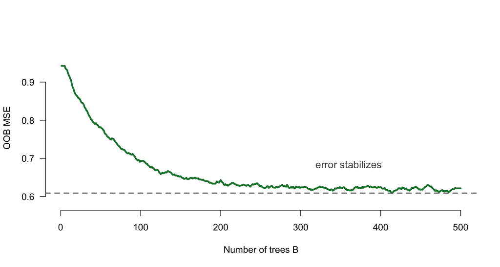

$\rightarrow$ choose B such that the error stabilizes

**When does adding more trees fail to reduce variance?**

## Random Forest

- correlation between trees diminishes variance reduction
- trees are trained on similar data

$\rightarrow$ trees utilize *similar predictors*

$\rightarrow$ predictions are correlated

**Solution:**

- only allow for a **few** randomly selected **predictors** $(m)$
- at each split, a subset of all predictors $(p)$ can be chosen
- random selection of predictors decorrelates trees and increases variance reduction
- rule of thumb: $m = \sqrt{p}$ for classification, $m = \frac{p}{3}$ for regression
- choosing the best $m$ by using OOB-Error

## Random Forest: Decorrelation of Trees

$p = 4$ predictors, $m = 2$ randomly selected predictors per split

Age, Education, Experience, Gender

**Tree 1**

```
%%{init: {"flowchart": {"curve": "basis", "nodeSpacing": 35, "rankSpacing": 50}, "themeVariables": {"fontFamily": "Arial", "fontSize": "15px"}}}%%
flowchart TD

    A["Age, Education<br/><br/>Best split:<br/>Education = University?"]
    A --> B["Experience, Gender<br/><br/>Best split:<br/>Experience < 5 years?"]
    A --> C["Age, Experience<br/><br/>Best split:<br/>Age < 40?"]

    B --> L1["32k"]
    B --> L2["48k"]

    C --> L3["61k"]
    C --> L4["84k"]

    classDef split fill:#ffffff,stroke:#188038,stroke-width:2px,color:#111;
    classDef leaf fill:#e6f4ea,stroke:#188038,stroke-width:2px,color:#111;

    class A,B,C split;
    class L1,L2,L3,L4 leaf;
```

**Tree 2**

```
%%{init: {"flowchart": {"curve": "basis", "nodeSpacing": 35, "rankSpacing": 50}, "themeVariables": {"fontFamily": "Arial", "fontSize": "15px"}}}%%
flowchart TD

    A2["Experience, Gender<br/><br/>Best split:<br/>Experience < 8 years?"]
    A2 --> B2["Age, Gender<br/><br/>Best split:<br/>Age < 35?"]
    A2 --> C2["Education, Gender<br/><br/>Best split:<br/>Education = Master?"]

    B2 --> L5["38k"]
    B2 --> L6["56k"]

    C2 --> L7["70k"]
    C2 --> L8["91k"]

    classDef split fill:#ffffff,stroke:#1a73e8,stroke-width:2px,color:#111;
    classDef leaf fill:#e8f0fe,stroke:#1a73e8,stroke-width:2px,color:#111;

    class A2,B2,C2 split;
    class L5,L6,L7,L8 leaf;
```

**Random Forestds** lead to **sharp reduction in variance**, while increasing the **bias slightly**!

## Gradient Boosting´s Motivation: Why do we need Boosting?

**Bagging / Random Forests**: reduce *variance* by averaging independent trees

**Boosting** → reduces *bias* by sequentially correcting mistakes

$$\boxed{\text{Error} = \text{Bias}^2 + \text{Variance} + \text{Noise}}$$

$$\boxed{\text{Error} = \color{red}{\underbrace{\color{black}{\text{Bias}^2}}_{\text{Boosting}}} + \color{red}{\underbrace{\color{black}{\text{Variance}\vphantom{\text{Bias}^2}}}_{\text{Random Trees/Bagging}}} + \text{Noise}}$$

## Intuition: How does Boosting work?

- Uses intentionally simple models that underfit badly (weak learners)
- Trees are then trained sequentially — each fixes the errors of the previous

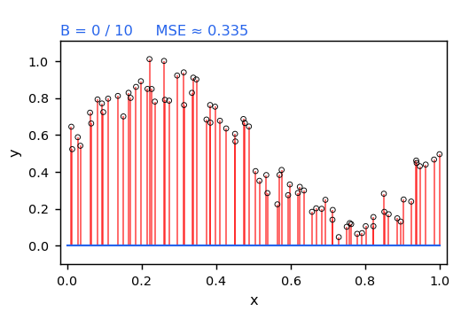

## The Algorithm: Fitting Residuals — The Core Idea: Learn From Your Mistakes

- After each tree, compute the residuals: how far off is the current prediction?
- The next tree is trained on those residuals — it learns to fix what went wrong
- Its correction is added to the current fit
- Repeat: residuals shrink, the overall fit improves
- The model never tries to get everything right at once — it learns slowly

## Boosting for Regression Trees

1. Start: predict $\hat{f}(x) = 0$, so residuals $r_i = y_i$ for all $i$
2. Repeat $B$ times:
   1. Fit a small tree to the residuals $r$
   2. Update: $\hat{f}(x) \leftarrow \hat{f}(x) + \lambda \cdot T_b(x)$
   3. Recompute residuals from the updated prediction
3. Final model: sum of all the small trees

Each tree is fit to the **mistakes** of the current ensemble, not to $Y$ directly

## Boosting for Regression Trees

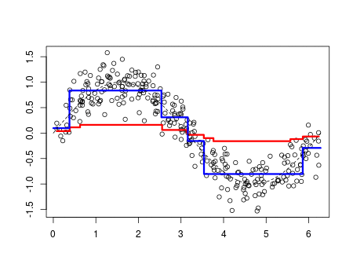

## The Learning Rate $\lambda$ — Shrinkage

$$\hat{f}(x) \leftarrow \hat{f}(x) + \lambda \cdot T_b(x)$$

- Each new tree is scaled down by $\lambda$ before being added — a **small cautious step**
- Think of it like a learning rate in any iterative method: smaller = more careful
- **Small $\lambda$** (e.g. 0.01): more trees needed, but usually better predictions
- **Large $\lambda$** (e.g. 0.5): learns fast, but risks overfitting
- Typical values: $\lambda = 0.01$ to $0.1$

**Trade-off:** smaller $\lambda$ requires more trees $B$ — but the extra computation is usually worth it

## The Effect of the Learning Rate

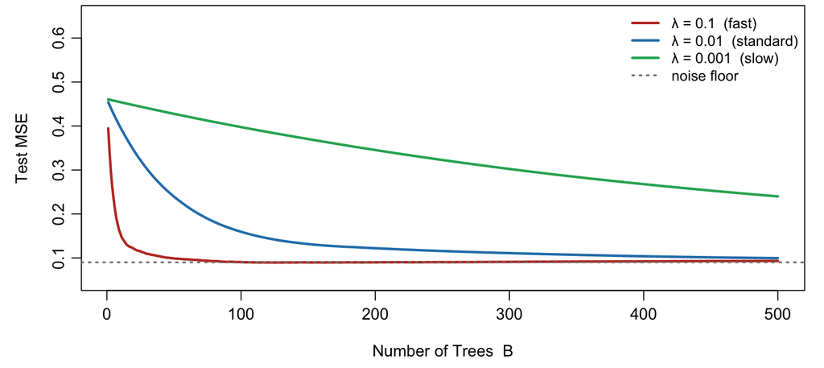

## Tree Depth and Interaction Order

- $d$ = number of splits per tree (the **tree depth**)
- Deeper trees can model interactions between variables

| Depth $d$ | What the model can capture |
| --- | --- |
| 1 (stump) | Each variable acts independently |
| 2 | Pairs of variables interact |
| 3+ | More complex interactions |

- $d = 1$ works surprisingly well in practice
- Deeper trees add complexity but also more variance
- In practice: $d \in \{1, 2, 3\}$ is usually enough

## Why is it called Gradient Boosting?

A **gradient** tells you: *in which direction should I move to reduce the error?*

- Think of standing on a hilly landscape — the gradient points **downhill**
- In machine learning: the gradient points toward **lower loss**
- Each boosting step moves the prediction a small step in that direction

For **squared error loss**, the gradient is simply the residual $r_i = y_i - \hat{f}(x_i)$

→ Fitting trees to residuals *is* gradient descent — we just never called it that

[interactive chart not shown]

Click anywhere on the height map to drop a ball and watch gradient descent find the valley

## Pseudo-Residuals

|  | Regression | Classification |
| --- | --- | --- |
| Prediction | a number | a probability |
| Error signal | $y_i - \hat{f}(x_i)$ | true label $-$ predicted prob. |
| Name | residual | **pseudo-residual** |

- Gradient boosting works for **any task** where you can define a loss

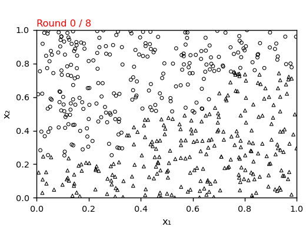

## Why Boosting Reduces Bias

- Boosting starts from a flat prediction — a heavily **underfitted** model
- Each new tree is directed exactly at the regions where the model is **still wrong**
- Over many iterations, the model fills in more and more of the true pattern
- Result: **bias decreases** steadily with each step

**Why not variance?** All trees are fit to the same dataset sequentially — they are correlated with each other. Averaging correlated models does not reduce variance much (unlike bagging).

## Bagging vs. Boosting — Direct Comparison

|  | **Bagging** | **Boosting** |
| --- | --- | --- |
| Tree fitting | Parallel, independent | Sequential, dependent |
| Data | Bootstrap samples | Original data (no resampling) |
| Error reduced | **Variance** | **Bias** |
| Base learner size | Deep | Shallow (stumps) |
| Overfitting risk | Low — more trees is safe | Yes, if $B$ or $\lambda$ too large |

## The Overfitting Risk — When Does Boosting Go Wrong?

Three failure modes and their remedies:

| Cause | Effect | Fix |
| --- | --- | --- |
| $B$ too large | Slow overfitting | Select $B$ by cross-validation |
| $\lambda$ too large | Fast overfitting | Use $\lambda \leq 0.1$ |
| $d$ too large | High-variance base learners | Keep $d \leq 3$ |

Boosting is **not immune** to overfitting — unlike bagging, test error will eventually rise.

## Practical Considerations: Three Tuning Parameters and Their Interplay

| Parameter | Role | Typical range |
| --- | --- | --- |
| $B$ — number of trees | Ensemble complexity | 100 – 5000 |
| $\lambda$ — learning rate | Step size / shrinkage | 0.001 – 0.1 |
| $d$ — tree depth | Interaction order | 1 – 5 |

**Core rule:** small $\lambda$ with large $B$ is standard practice — slower but more regularized.

All three interact: reducing $\lambda$ by $10\times$ typically requires $10\times$ more trees to match performance.

## Data Example: Setup

**Simulation setup:**

- True function: $f(x) = \sin(x)$
- Noise: $\varepsilon \sim \mathcal{N}(0,\; 0.3^2)$
- $n = 150$ train, $n = 50$ test, $x_i \overset{iid}{\sim} \mathrm{U}(0, 2\pi)$

**Goal:** Recover $\sin(x)$ with gradient boosting

- Base learner: stumps ($d = 1$)
- Vary $\lambda \in \{0.1,\; 0.01,\; 0.001\}$, fix $B = 500$

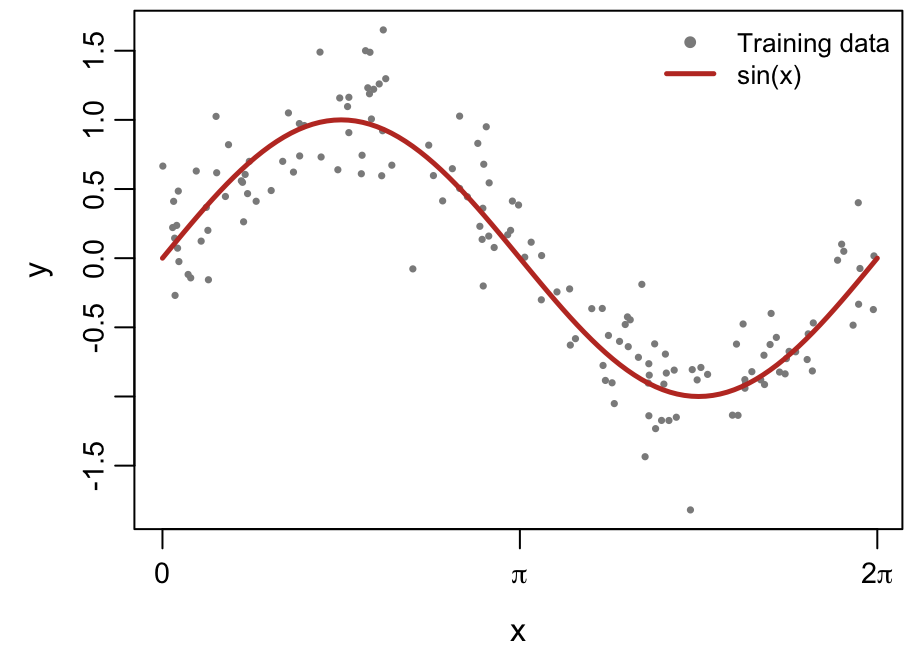

## Data Example: Code

```python
import numpy as np
from sklearn.tree import DecisionTreeRegressor

np.random.seed(2024)
x_tr = np.sort(np.random.uniform(0, 2 * np.pi, 150))
y_tr = np.sin(x_tr) + np.random.normal(0, 0.3, 150)

def boost_run(lam, B=500):
    f = np.zeros(len(x_tr))
    for b in range(B):
        r = y_tr - f                           # residuals
        stump = DecisionTreeRegressor(max_depth=1)
        stump.fit(x_tr.reshape(-1, 1), r)
        f += lam * stump.predict(x_tr.reshape(-1, 1))

res_a = boost_run(lam=0.1)
res_b = boost_run(lam=0.01)
res_c = boost_run(lam=0.001)
```

## Data Example: Results

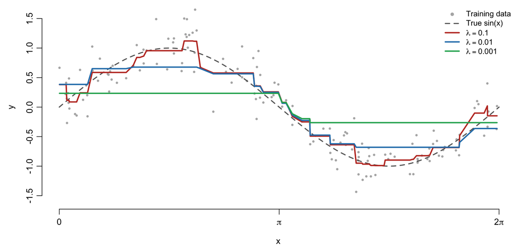

## Exercise 1 — Trace the Algorithm

Consider the following tiny dataset with $n = 4$ observations:

| $i$ | $x_i$ | $y_i$ |
| --- | --- | --- |
| 1 | 1 | 3 |
| 2 | 2 | 5 |
| 3 | 3 | 4 |
| 4 | 4 | 8 |

Use $\lambda = 0.5$ and stumps ($d = 1$). Start from $\hat{f}(x) = 0$.

**(a)** Compute the residuals $r_i = y_i - \hat{f}(x_i)$ after initialization.

**(b)** A stump fit to the residuals splits at $x = 2.5$, predicting $\bar{r}_{\text{left}} = 4$ for $x \leq 2.5$ and $\bar{r}_{\text{right}} = 6$ for $x > 2.5$. Update $\hat{f}(x)$ using the learning rate.

**(c)** Recompute the residuals. Are they smaller? Which observation still has the largest residual?

**(d)** Why does boosting use $\lambda < 1$ instead of just adding the full tree prediction?

## Exercise 1 — Solution

**(a)** Since $\hat{f}(x) = 0$, residuals equal the responses: $r = (3,\; 5,\; 4,\; 8)$

**(b)** Left group ($x \leq 2.5$: obs. 1, 2): add $\lambda \cdot 4 = 0.5 \times 4 = 2$. Right group ($x > 2.5$: obs. 3, 4): add $\lambda \cdot 6 = 0.5 \times 6 = 3$.

$$\hat{f} = (0{+}2,\; 0{+}2,\; 0{+}3,\; 0{+}3) = (2,\; 2,\; 3,\; 3)$$

**(c)** New residuals $r_i = y_i - \hat{f}(x_i)$:

| $i$ | $y_i$ | $\hat{f}$ | $r_i$ (before) | $r_i$ (after) |
| --- | --- | --- | --- | --- |
| 1 | 3 | 2 | 3 | **1** |
| 2 | 5 | 2 | 5 | **3** |
| 3 | 4 | 3 | 4 | **1** |
| 4 | 8 | 3 | 8 | **5** |

Yes — all residuals shrank. Observation 4 still has the largest residual ($r_4 = 5$).

**(d)** Adding the full tree ($\lambda = 1$) would jump directly to the residuals — a large, noisy step that risks overfitting. Scaling by $\lambda < 1$ takes a cautious partial step, leaving room for subsequent trees to correct what remains.

## Exercise 2 — Conceptual Questions

**(a)** Bagging and boosting both combine many trees, yet they target different sources of error. Which source does each method reduce, and why?

**(b)** You train a boosted model with $\lambda = 0.5$ and $B = 200$ trees and notice the test error starts rising after $B = 80$. What is happening, and what are two ways to fix it?

**(c)** A colleague suggests that since deeper trees are more expressive, you should always use $d = 10$ in gradient boosting. Do you agree? What is the trade-off?

**(d)** For squared-error loss, fitting trees to residuals *is* gradient descent. What plays the role of the “gradient” in this case?

## Exercise 2 — Solution

**(a)** Bagging reduces **variance** — averaging many independent trees trained on bootstrap samples cancels out random fluctuations. Boosting reduces **bias** — each tree is directed at the regions where the current model is still wrong, gradually filling in the true pattern. Boosting’s trees are correlated (same data, sequential), so averaging them does little for variance.

**(b)** The model is **overfitting** — $\lambda = 0.5$ is too large, so each tree takes an aggressive step and the ensemble eventually memorises the training data. Two fixes: (1) reduce $\lambda$ (e.g. to 0.01–0.1) and increase $B$ to compensate; (2) use cross-validation to select $B$ and stop early (here, at $B = 80$).

**(c)** Disagree. Deeper trees have higher variance, and boosting is already designed around shallow learners — the sequential correction handles bias. Using $d = 10$ adds unnecessary variance without much gain. In practice $d \in \{1, 2, 3\}$ is almost always enough.

**(d)** The **residual** $r_i = y_i - \hat{f}(x_i)$ is the negative gradient of the squared-error loss with respect to $\hat{f}(x_i)$. Fitting a tree to the residuals is exactly one step of gradient descent in the space of predictions.

## Key Takeaways

- Boosting builds a strong model by **sequentially correcting mistakes** with small trees
- Each tree fits the **residuals** — what the current ensemble got wrong
- This reduces **bias** — different from bagging, which reduces variance
- Three knobs: number of trees $B$, learning rate $\lambda$, tree depth $d$
- Small $\lambda$ + many trees is the standard recipe
- In practice: **XGBoost, LightGBM, CatBoost** are the go-to implementations

## Modern Gradient Boosting Libraries

In practice, we usually do **not** implement gradient boosting from scratch. Instead, we use mature software libraries.

| Library | Simple Introduction |
| --- | --- |
| **scikit-learn Gradient Boosting** | Basic version, good for learning and small demos |
| **XGBoost** | Classic and widely used, strong and stable performance |
| **LightGBM** | Faster and more memory-efficient, good for large datasets |
| **CatBoost** | Good at handling categorical variables directly |

## How Are They Different?

| Library | Main Strength | When to Use |
| --- | --- | --- |
| **scikit-learn** | Easy to use | Classroom demos, small datasets |
| **XGBoost** | Strong general performance | Competitions, industry, tabular data |
| **LightGBM** | Speed and low memory use | Large datasets |
| **CatBoost** | Categorical feature support | Data with many categories |

## Common Workflow

Most modern gradient boosting libraries follow a similar workflow.

| Step | What happens |
| --- | --- |
| **1. Load data** | Prepare the dataset |
| **2. Train-test split** | Separate data for training and evaluation |
| **3. Fit model** | Train the gradient boosting model |
| **4. Predict** | Use the model on test data |
| **5. Evaluate** | Check accuracy, RMSE, or another metric |

model = Model(…)  
model.fit(X_train, y_train)  
pred = model.predict(X_test)  
score = metric(y_test, pred)

## Demo Setup: Breast Cancer Classification

For the demo, I use the **Breast Cancer dataset** from scikit-learn.

| Item | Description |
| --- | --- |
| **Task** | Predict whether a tumor is benign or malignant |
| **Dataset type** | Standard benchmark classification dataset |
| **Model** | XGBoost classifier |
| **Evaluation metric** | Accuracy |

This is a simple demo showing how to fit a modern gradient boosting model.

## Fitting XGBoost on a Benchmark Dataset

```python
from sklearn.datasets import load_breast_cancer
from sklearn.model_selection import train_test_split
from sklearn.metrics import accuracy_score
from xgboost import XGBClassifier

X, y = load_breast_cancer(return_X_y=True)

X_train, X_test, y_train, y_test = train_test_split(
    X, y, test_size=0.2, random_state=42
)

model = XGBClassifier(
    n_estimators=100,
    learning_rate=0.1,
    max_depth=3
)

model.fit(X_train, y_train)
pred = model.predict(X_test)

print("Accuracy:", accuracy_score(y_test, pred))
```

[output not shown]

## Interpretation

In this demo, XGBoost builds many small decision trees sequentially.

Each new tree tries to improve the mistakes made by the previous trees.

The learning rate controls how much each tree contributes to the final model.

So this demo connects directly to the idea of gradient boosting:  
**Sequential learning + error correction**